# Évaluation comparatives des modèles

Ce notebook sert à comparer les performances des trois modèles que nous avons entraînés et testés dans les notebooks 06, 07 et 08.

Il lit en entrée les données des fichiers "data/resultats/test_reg_lin.csv", "data/resultats/test_pmc.csv" et "data/resultats/test_rnd_forest.csv".  
Il produit en sortie le fichier "data/resultats/test_merged.csv" qui contient les résultats globaux des tests.

```python
import pandas as pd
import matplotlib.pyplot as plt
from statistics import mean
```

```python
df = pd.read_csv("data/resultats/test_reg_lin.csv", sep=";")
df_pmc = pd.read_csv("data/resultats/test_pmc.csv", sep=";")
df_rndf = pd.read_csv("data/resultats/test_rnd_forest.csv", sep=";")
```

```python
# renommage des colonnes de prédictions
df = df.rename(columns={"predicted_score": "pred_reg_lin"})
df_pmc = df_pmc.rename(columns={"predicted_score": "pred_pmc"})
df_rndf = df_rndf.rename(columns={"predicted_score": "pred_rnd_forest"})
```

```python
# Regroupement des colonnes de prédiction dans le même data frame.
df["pred_pmc"] = df_pmc["pred_pmc"]
df["pred_rnd_forest"] = df_rndf["pred_rnd_forest"]

# Supression de la colonne qui n'est plus utile.
df = df.drop(columns='cluster_init')
```

```python
df
```

|  | annee | Country | Happiness Score | nativity | migration | health_expend | educ_expend | gdp | taxes | budget | milit | cluster3 | cluster6 | pred_reg_lin | pred_pmc | pred_rnd_forest |
| --- | --- | --- | --- | --- | --- | --- | --- | --- | --- | --- | --- | --- | --- | --- | --- | --- |
| 0 | 2019 | Bahrain | 6.1990 | 13.10 | 11.60 | 4.9 | 2.3 | 49000.0 | 16.60 | -10.1 | 3.600000 | 0 | 4 | 6.102281 | 6.467802 | 6.159557 |
| 1 | 2023 | Russia | 5.6610 | 9.22 | 1.70 | 7.6 | 3.7 | 28000.0 | 10.83 | -1.4 | 5.400000 | 0 | 5 | 5.917161 | 5.842086 | 5.941517 |
| 2 | 2020 | Jordan | 4.6334 | 23.00 | -11.30 | 8.1 | 3.1 | 3291.0 | 23.60 | -5.1 | 4.700000 | 2 | 2 | 4.811708 | 4.393599 | 3.859309 |
| 3 | 2021 | Poland | 6.1660 | 8.69 | -0.33 | 6.3 | 4.6 | 32200.0 | 39.50 | -1.7 | 2.200000 | 0 | 5 | 6.185825 | 6.123789 | 6.189483 |
| 4 | 2023 | Norway | 7.3150 | 11.89 | 3.89 | 11.4 | 5.9 | 65700.0 | 21.09 | 4.4 | 1.740000 | 1 | 1 | 7.062323 | 7.573119 | 7.127334 |
| ... | ... | ... | ... | ... | ... | ... | ... | ... | ... | ... | ... | ... | ... | ... | ... | ... |
| 263 | 2017 | Venezuela | 5.2500 | 18.80 | -1.20 | 5.3 | 6.9 | 14000.0 | 34.40 | -48.0 | 1.000000 | 2 | 2 | 5.459064 | 5.449699 | 5.573255 |
| 264 | 2016 | Namibia | 4.5740 | 27.90 | 0.00 | 8.9 | 8.3 | 11400.0 | 35.50 | -5.5 | 4.200000 | 2 | 0 | 5.273118 | 4.372682 | 4.562659 |
| 265 | 2018 | Brazil | 6.4190 | 13.90 | -0.10 | 8.3 | 5.9 | 15600.0 | 35.70 | -1.1 | 1.320000 | 2 | 2 | 5.728380 | 6.031221 | 6.334489 |
| 266 | 2016 | Bhutan | 5.1960 | 17.50 | 0.00 | 3.6 | 5.9 | 8200.0 | 27.50 | -3.8 | 2.152823 | 2 | 0 | 5.206978 | 5.238331 | 5.445467 |
| 267 | 2016 | Senegal | 4.2190 | 34.00 | -1.50 | 4.7 | 5.6 | 2500.0 | 25.10 | -4.8 | 1.890000 | 2 | 0 | 4.430199 | 4.286149 | 3.908814 |

268 rows × 16 columns

## Calcul manuel des R<sup>2</sup> pour les trois modèles

#### Pour la régression linéaire

```python
u = sum((df["Happiness Score"] - df.pred_reg_lin)**2)
v = sum((df["Happiness Score"] - mean(df.pred_reg_lin))**2)
1 - u/v
```

```
0.6199348783264008
```

#### Pour le perceptron multicouches

```python
u = sum((df["Happiness Score"] - df.pred_pmc)**2)
v = sum((df["Happiness Score"] - mean(df.pred_pmc))**2)
1 - u/v
```

```
0.779694191183545
```

#### Pour la forest aléatoire

```python
u = sum((df["Happiness Score"] - df.pred_rnd_forest)**2)
v = sum((df["Happiness Score"] - mean(df.pred_rnd_forest))**2)
1 - u/v
```

```
0.8847690572468936
```

Globalement, c'est la forêt aléatoire qui offre les meilleures performances.

### Graphique comparatif des résidus

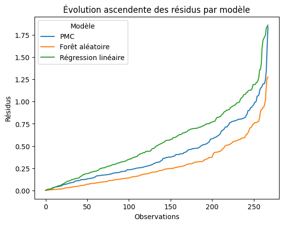

```python
res_rl = abs(df["Happiness Score"] - df.pred_reg_lin).sort_values(ignore_index=True)
res_pmc = abs(df["Happiness Score"] - df.pred_pmc).sort_values(ignore_index=True)
res_rndf = abs(df["Happiness Score"] - df.pred_rnd_forest).sort_values(ignore_index=True)

fig, ax = plt.subplots()

plt.plot(res_pmc.index ,res_pmc)
plt.plot(res_rndf.index ,res_rndf)
plt.plot(res_rl.index ,res_rl)
plt.xlabel("Observations")
plt.ylabel("Résidus")

ax.set_title("Évolution ascendente des résidus par modèle")
ax.legend(["PMC","Forêt aléatoire","Régression linéaire"], loc="upper left", title="Modèle")

plt.show()
```

On voit bien que le modèle forêt aléatoire donne des résidus plus bas. Ce qui indique globalement une meilleure performance.

### Identification du meilleur modèle pour chaque ligne de l'ensemble de tests.

```python
def determin_best_model(li):
    d_rndf = abs(li["Happiness Score"] - li.pred_rnd_forest)
    d_rl = abs(li["Happiness Score"] - li.pred_reg_lin)
    d_pmc = abs(li["Happiness Score"] - li.pred_pmc)
    min_d = min(d_rndf, d_rl, d_pmc)
    if min_d == d_rndf:
        return("random forest")
    if min_d == d_rl:
        return("regression lineaire")
    else:
        return("pmc")
```

```python
df["Meilleur_modele"] = df.apply(determin_best_model, axis=1)
```

```python
df
```

|  | annee | Country | Happiness Score | nativity | migration | health_expend | educ_expend | gdp | taxes | budget | milit | cluster3 | cluster6 | pred_reg_lin | pred_pmc | pred_rnd_forest | Meilleur_modele |
| --- | --- | --- | --- | --- | --- | --- | --- | --- | --- | --- | --- | --- | --- | --- | --- | --- | --- |
| 0 | 2019 | Bahrain | 6.1990 | 13.10 | 11.60 | 4.9 | 2.3 | 49000.0 | 16.60 | -10.1 | 3.600000 | 0 | 4 | 6.102281 | 6.467802 | 6.159557 | random forest |
| 1 | 2023 | Russia | 5.6610 | 9.22 | 1.70 | 7.6 | 3.7 | 28000.0 | 10.83 | -1.4 | 5.400000 | 0 | 5 | 5.917161 | 5.842086 | 5.941517 | pmc |
| 2 | 2020 | Jordan | 4.6334 | 23.00 | -11.30 | 8.1 | 3.1 | 3291.0 | 23.60 | -5.1 | 4.700000 | 2 | 2 | 4.811708 | 4.393599 | 3.859309 | regression lineaire |
| 3 | 2021 | Poland | 6.1660 | 8.69 | -0.33 | 6.3 | 4.6 | 32200.0 | 39.50 | -1.7 | 2.200000 | 0 | 5 | 6.185825 | 6.123789 | 6.189483 | regression lineaire |
| 4 | 2023 | Norway | 7.3150 | 11.89 | 3.89 | 11.4 | 5.9 | 65700.0 | 21.09 | 4.4 | 1.740000 | 1 | 1 | 7.062323 | 7.573119 | 7.127334 | random forest |
| ... | ... | ... | ... | ... | ... | ... | ... | ... | ... | ... | ... | ... | ... | ... | ... | ... | ... |
| 263 | 2017 | Venezuela | 5.2500 | 18.80 | -1.20 | 5.3 | 6.9 | 14000.0 | 34.40 | -48.0 | 1.000000 | 2 | 2 | 5.459064 | 5.449699 | 5.573255 | pmc |
| 264 | 2016 | Namibia | 4.5740 | 27.90 | 0.00 | 8.9 | 8.3 | 11400.0 | 35.50 | -5.5 | 4.200000 | 2 | 0 | 5.273118 | 4.372682 | 4.562659 | random forest |
| 265 | 2018 | Brazil | 6.4190 | 13.90 | -0.10 | 8.3 | 5.9 | 15600.0 | 35.70 | -1.1 | 1.320000 | 2 | 2 | 5.728380 | 6.031221 | 6.334489 | random forest |
| 266 | 2016 | Bhutan | 5.1960 | 17.50 | 0.00 | 3.6 | 5.9 | 8200.0 | 27.50 | -3.8 | 2.152823 | 2 | 0 | 5.206978 | 5.238331 | 5.445467 | regression lineaire |
| 267 | 2016 | Senegal | 4.2190 | 34.00 | -1.50 | 4.7 | 5.6 | 2500.0 | 25.10 | -4.8 | 1.890000 | 2 | 0 | 4.430199 | 4.286149 | 3.908814 | pmc |

268 rows × 17 columns

## Sauvegarde du fichier contenant la concaténation des résultats

```python
# Sauvegarde du data frame des résultats de tests
df.to_csv("data/resultats/test_merged.csv", sep=";", index=False)
```

## Décompte des meilleurs modèles

Dans cette section, nous allons comparer le nombre de lignes du jeu de tests selon son meilleur modèle associé.

```python
cpts = df.groupby("Meilleur_modele")["Meilleur_modele"].count()
```

```python
cpts
```

```
Meilleur_modele
pmc                     60
random forest          151
regression lineaire     57
Name: Meilleur_modele, dtype: int64
```

### Diagramme global

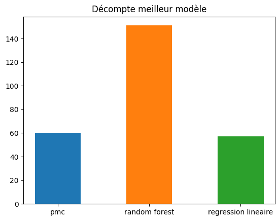

```python
fig, ax = plt.subplots()

for i in range(len(cpts)):
    p = ax.bar(cpts.index[i], cpts[i], 0.5)

ax.set_title("Décompte meilleur modèle")

plt.show()
```

### Par regroupement, avec k=3 regroupements

```python
cpts = df.groupby(["cluster3", "Meilleur_modele"])["Meilleur_modele"].count()
```

```python
cpts
```

```
cluster3  Meilleur_modele
0         pmc                     18
          random forest           33
          regression lineaire     19
1         pmc                      4
          random forest            7
          regression lineaire      2
2         pmc                     38
          random forest          111
          regression lineaire     36
Name: Meilleur_modele, dtype: int64
```

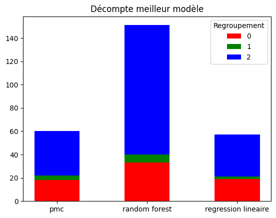

```python
fig, ax = plt.subplots()

ax.bar(cpts[0,].index, cpts[0,], color='r', width=0.5)
ax.bar(cpts[0,].index, cpts[1,], bottom=cpts[0,], color='g', width=0.5)
ax.bar(cpts[0,].index, cpts[2,], bottom=cpts[1,]+cpts[0,], color='b', width=0.5)
ax.set_title("Décompte meilleur modèle")
ax.legend([0,1,2], loc="upper right", title="Regroupement")
plt.show()
```

### Par regroupement, avec k=6 regroupements

```python
cpts = df.groupby([pd.Categorical(df.cluster6), pd.Categorical(df.Meilleur_modele)])["Meilleur_modele"].count().fillna(0)
```

```python
cpts
```

```
0  pmc                    22
   random forest          67
   regression lineaire    18
1  pmc                     3
   random forest           8
   regression lineaire     2
2  pmc                    16
   random forest          42
   regression lineaire    18
3  pmc                     2
   random forest           1
   regression lineaire     0
4  pmc                     8
   random forest          15
   regression lineaire     3
5  pmc                     9
   random forest          18
   regression lineaire    16
Name: Meilleur_modele, dtype: int64
```

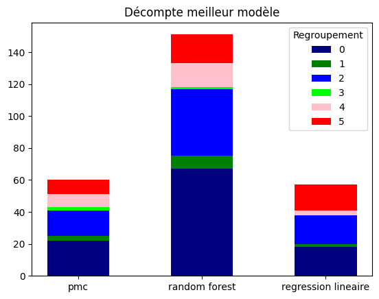

```python
fig, ax = plt.subplots()

ax.bar(cpts[0,].index, cpts[0,], color='navy', width=0.5)
ax.bar(cpts[0,].index, cpts[1,], bottom=cpts[0,], color='g', width=0.5)
ax.bar(cpts[0,].index, cpts[2,], bottom=cpts[0,]+cpts[1,], color='b', width=0.5)
ax.bar(cpts[0,].index, cpts[3,], bottom=cpts[0,]+cpts[1,]+cpts[2,], color='lime', width=0.5)
ax.bar(cpts[0,].index, cpts[4,], bottom=cpts[0,]+cpts[1,]+cpts[2,]+cpts[3,], color='pink', width=0.5)
ax.bar(cpts[0,].index, cpts[5,], bottom=cpts[0,]+cpts[1,]+cpts[2,]+cpts[3,]+cpts[4,], color='r', width=0.5)
ax.set_title("Décompte meilleur modèle")
ax.legend([0,1,2,3,4,5], loc="upper right", title="Regroupement")
plt.show()
```

On peut voir visuellement que le regroupement 4 est sous représenté dans la bande de la régression linéaire, alors que le regroupement 5 y est plutôt surreprésenté.  
Comme nous avons vu dans le notebook 04, ces deux regroupements s'apparente grandement au regroupement 0 lorsque nous avions 3 regroupements.  
L'algorithme k-means avait bien décelé cette nuance.